# Introduction to optedr: optimal designs for non-linear models

```r
library(optedr)
```

## The optimal design problem

In non-linear regression the information that an experiment provides about the model parameters depends on *where* observations are taken, not just how many. The Fisher information matrix at a design point $x$ is

$$M(\xi) = \int f(x)\, f(x)^{\top} \,
\xi(dx),$$

where $f(x) = \nabla_\theta \mu(x, \theta)$ is the gradient of the mean response. Different optimality criteria summarise $M(\xi)$ into a single number to minimise:

| Criterion | Objective | Key argument |
| --- | --- | --- |
| D-Optimality | $-\log\det M$ | — |
| Ds-Optimality | focuses on a subset of parameters | `par_int` |
| A-Optimality | $\operatorname{tr} M^{-1}$ | — |
| I-Optimality | integrated prediction variance over a region | `reg_int` |
| L-Optimality | $\operatorname{tr}(B \, M^{-1})$ for user-supplied $B$ | `matB` |

All are computed with `opt_des()`, which implements the cocktail algorithm (Yu, 2011).

## A first example: D-Optimality in one factor

The Antoine equation models vapour pressure as a function of temperature. With two parameters and one design variable the D-optimal design has exactly two support points.

```r
result_D <- opt_des(
  criterion    = "D-Optimality",
  model        = y ~ a * exp(-b / x),
  parameters   = c("a", "b"),
  par_values   = c(1, 1500),
  design_space = c(212, 422)
)
```

```
#>
#> ℹ Stop condition not reached, max iterations performed
#> ⠙ Calculating optimal design 22 done (24/s) | 927msℹ The lower bound for efficiency is 99.9982181686267%
#>
```

```r
result_D
```

```
#> Optimal design for D-Optimality:
#>      Point    Weight
#> 1 329.2963 0.5000089
#> 2 422.0000 0.4999911
```

`plot()` shows the sensitivity function $d(x, \xi)$. By the Equivalence Theorem the design is optimal if and only if $d(x, \xi) \leq k$ everywhere, with equality at every support point.

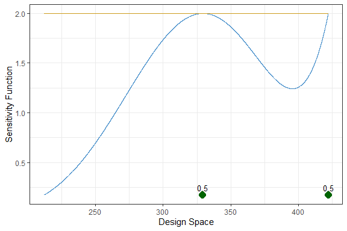

Sensitivity function for the D-optimal design.

```r
plot(result_D)
```

`summary()` gives a fuller breakdown including the criterion value and convergence diagnostics.

```r
summary(result_D)
```

```
#> Model:
#> y ~ a * exp(-b/x)
#> Weight function:
#> function (x)
#> 1
#>
#> Optimal design for D-Optimality:
#>      Point    Weight
#> 1 329.2963 0.5000089
#> 2 422.0000 0.4999911
#>
#> Minimum efficiency (Atwood): 99.9982181686267%
#> Criterion value:             9.97281e+06
```

The `$atwood` component reports the Atwood criterion (percentage deviation from the theoretical optimum bound): values close to 100 % confirm convergence.

## Other optimality criteria

### Ds-Optimality

`par_int` selects the indices of the parameters of interest. Here we focus only on `th0`:

```r
result_Ds <- opt_des(
  criterion    = "Ds-Optimality",
  model        = y ~ th0 * exp(x / th1),
  parameters   = c("th0", "th1"),
  par_values   = c(10.4963, -3.2940),
  design_space = c(0.94, 30),
  par_int      = c(1)
)
```

```
#>
#> ℹ Stop condition reached: difference between sensitivity and criterion < 1e-05
#> ⠙ Calculating optimal design 9 done (24/s) | 384msℹ The lower bound for efficiency is 99.9998969351635%
#>
```

```r
result_Ds
```

```
#> Optimal design for Ds-Optimality:
#>      Point    Weight
#> 1 0.940000 0.6042053
#> 2 5.147919 0.3957947
```

### A-Optimality

Minimises the average variance of the parameter estimators:

```r
result_A <- opt_des(
  criterion    = "A-Optimality",
  model        = y ~ a * exp(-b / x),
  parameters   = c("a", "b"),
  par_values   = c(1, 1500),
  design_space = c(212, 422)
)
```

```
#>
#> ℹ Stop condition not reached, max iterations performed
#> ⠙ Calculating optimal design 22 done (25/s) | 886msℹ The lower bound for efficiency is 99.9999982911678%
#>
```

```r
result_A
```

```
#> Optimal design for A-Optimality:
#>      Point    Weight
#> 1 310.3784 0.7821613
#> 2 422.0000 0.2178387
```

### I-Optimality

Minimises the integrated prediction variance over a region of interest `reg_int`. Useful when prediction in a specific sub-range matters more than global estimation:

```r
result_I <- opt_des(
  criterion    = "I-Optimality",
  model        = y ~ a * exp(-b / x),
  parameters   = c("a", "b"),
  par_values   = c(1, 1500),
  design_space = c(212, 422),
  reg_int      = c(380, 422)
)
```

```
#>
#> ℹ Stop condition reached: difference between sensitivity and criterion < 1e-05
#> ⠙ Calculating optimal design 5 done (28/s) | 178msℹ The lower bound for efficiency is 99.9999993787934%
#>
```

```r
result_I
```

```
#> Optimal design for I-Optimality:
#>     Point    Weight
#> 1 357.518 0.4346119
#> 2 422.000 0.5653881
```

### L-Optimality

`matB` is a symmetric positive-semidefinite $k \times k$ matrix that selects which variances to minimise. Setting `matB = diag(c(1, 0))` focuses entirely on the variance of `a`:

```r
result_L <- opt_des(
  criterion    = "L-Optimality",
  model        = y ~ a * exp(-b / x),
  parameters   = c("a", "b"),
  par_values   = c(1, 1500),
  design_space = c(212, 422),
  matB         = diag(c(1, 0))
)
```

```
#>
#> ℹ Stop condition reached: difference between sensitivity and criterion < 1e-05
#> ⠙ Calculating optimal design 22 done (22/s) | 998msℹ The lower bound for efficiency is 99.9999982893632%
#>
```

```r
result_L
```

```
#> Optimal design for L-Optimality:
#>      Point    Weight
#> 1 310.3784 0.7253377
#> 2 422.0000 0.2746623
```

Comparing D- and L-optimal designs shows how the support points shift when precision is concentrated on one parameter:

```r
cat("D-optimal support:\n"); print(result_D$optdes)
```

```
#> D-optimal support:
#>      Point    Weight
#> 1 329.2963 0.5000089
#> 2 422.0000 0.4999911
```

```r
cat("L-optimal support:\n"); print(result_L$optdes)
```

```
#> L-optimal support:
#>      Point    Weight
#> 1 310.3784 0.7253377
#> 2 422.0000 0.2746623
```

## Multi-dimensional design spaces

For models with two or more design variables pass `design_space` as a named list. Variable names in the list must match those used in `model`.

### Two-factor model: bisubstrate Michaelis-Menten

Enzyme kinetics with two substrates: $\mu = V_{\max} x_1 x_2 / [(K_1 + x_1)(K_2 + x_2)]$.

```r
result_2D <- opt_des(
  criterion    = "D-Optimality",
  model        = y ~ Vmax * x1 * x2 / ((K1 + x1) * (K2 + x2)),
  parameters   = c("Vmax", "K1", "K2"),
  par_values   = c(1, 1, 1),
  design_space = list(x1 = c(0.1, 10), x2 = c(0.1, 10))
)
```

```
#>
#> ℹ Stop condition reached: difference between sensitivity and criterion < 1e-05
#> ⠙ Calculating optimal design 17 done (10/s) | 1.7sℹ The lower bound for efficiency is 99.9990280062951%
#>
```

```r
result_2D
```

```
#> Optimal design for D-Optimality (2 factors):
#>           x1         x2    Weight
#> 1  0.8335868 10.0000000 0.3333301
#> 2 10.0000000  0.8331407 0.3333398
#> 3 10.0000000 10.0000000 0.3333301
```

`plot()` for a two-factor model returns a viridis heatmap of the sensitivity function, with the support points overlaid in red:

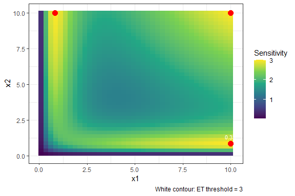

Sensitivity heatmap for the 2D D-optimal design.

```r
plot(result_2D)
```

L-Optimality extends naturally to multi-dimensional spaces. Here we minimise only the variance of $K_1$:

```r
result_2D_L <- opt_des(
  criterion    = "L-Optimality",
  model        = y ~ Vmax * x1 * x2 / ((K1 + x1) * (K2 + x2)),
  parameters   = c("Vmax", "K1", "K2"),
  par_values   = c(1, 1, 1),
  design_space = list(x1 = c(0.1, 10), x2 = c(0.1, 10)),
  matB         = diag(c(0, 1, 0))
)
```

[output not shown]

[output cut: 88 more lines]

[output not shown]

```r
result_2D_L
```

```
#> Optimal design for L-Optimality (2 factors):
#>           x1 x2    Weight
#> 1  0.6042692 10 0.7070488
#> 2 10.0000000 10 0.2929512
```

### Three factors and beyond

For $d \geq 3$ factors `plot()` switches to a scatter-matrix with $\binom{d}{2}$ panels, one per pair of variables. Point size is proportional to weight.

```r
result_3D <- opt_des(
  criterion    = "D-Optimality",
  model        = y ~ Vmax * x1 * x2 * x3 / ((K1+x1) * (K2+x2) * (K3+x3)),
  parameters   = c("Vmax", "K1", "K2", "K3"),
  par_values   = c(1, 1, 1, 1),
  design_space = list(x1 = c(0.1, 10), x2 = c(0.1, 10), x3 = c(0.1, 10))
)
```

[output not shown]

```r
result_3D
```

```
#> Optimal design for D-Optimality (3 factors):
#>           x1         x2         x3    Weight
#> 1  0.8329102 10.0000000 10.0000000 0.2499977
#> 2 10.0000000 10.0000000  0.8342591 0.2499978
#> 3 10.0000000  0.8337413 10.0000000 0.2500067
#> 4 10.0000000 10.0000000 10.0000000 0.2499977
```

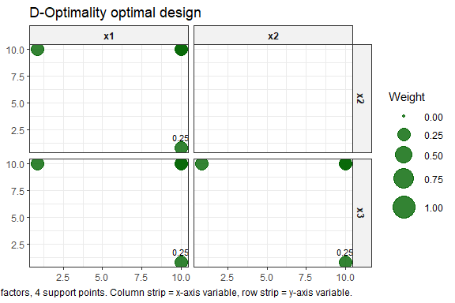

```r
plot(result_3D)
```

## Compound criterion

Sometimes no single criterion captures the experimental goals. `criterion = "Compound"` combines any set of criteria as a weighted sum of their sensitivity functions. Weights are normalised automatically.

```r
result_DI <- opt_des(
  criterion    = "Compound",
  model        = y ~ 10^(a - b / (c + x)),
  parameters   = c("a", "b", "c"),
  par_values   = c(8.07131, 1730.63, 233.426),
  design_space = c(1, 100),
  compound     = list(
    list(criterion = "D-Optimality", weight = 0.7),
    list(criterion = "I-Optimality", weight = 0.3, reg_int = c(60, 100))
  )
)
```

[output not shown]

```r
result_DI
```

```
#> Optimal design for Compound (0.70*D + 0.30*I):
#>       Point    Weight
#> 1  46.50267 0.3047727
#> 2  82.87444 0.4062833
#> 3 100.00000 0.2889441
```

Comparing with the pure D-optimal design shows how the composite shifts one support point toward the prediction region:

```r
result_D_ant <- opt_des(
  "D-Optimality",
  y ~ 10^(a - b / (c + x)), c("a", "b", "c"),
  c(8.07131, 1730.63, 233.426), c(1, 100)
)
```

```
#>
#> ℹ Stop condition not reached, max iterations performed
#> ⠙ Calculating optimal design 22 done (16/s) | 1.4sℹ The lower bound for efficiency is 99.9986187558838%
#>
```

```r
cat("D-optimal:\n");         print(result_D_ant$optdes)
```

```
#> D-optimal:
#>       Point    Weight
#> 1  44.90080 0.3333415
#> 2  83.19032 0.3333292
#> 3 100.00000 0.3333293
```

```r
cat("Compound D+I (70/30):\n"); print(result_DI$optdes)
```

```
#> Compound D+I (70/30):
#>       Point    Weight
#> 1  46.50267 0.3047727
#> 2  82.87444 0.4062833
#> 3 100.00000 0.2889441
```

## Design efficiency

`design_efficiency()` measures the fraction of the optimal information that a given design achieves: an efficiency of 0.80 means the design needs $1/0.8 = 1.25\times$ more observations to match the optimal.

```r
design_ad_hoc <- data.frame(
  Point  = c(220, 300, 400),
  Weight = c(1/3, 1/3, 1/3)
)
eff <- design_efficiency(design_ad_hoc, result_D)
```

```
#> ℹ The efficiency of the design is 47.3464225136928%
```

```r
cat("Efficiency of ad-hoc design:", round(eff * 100, 2), "%\n")
```

```
#> Efficiency of ad-hoc design: 47.35 %
```

For multi-dimensional designs pass a data frame with one column per factor plus a `Weight` column:

```r
corners_2d <- data.frame(
  x1     = c(0.1, 10,  0.1, 10),
  x2     = c(0.1, 0.1, 10,  10),
  Weight = rep(0.25, 4)
)
eff_2d <- design_efficiency(corners_2d, result_2D)
```

```
#> ℹ The efficiency of the design is 19.3350600942303%
```

```r
cat("Efficiency of corner design vs 2D D-optimal:", round(eff_2d * 100, 2), "%\n")
```

```
#> Efficiency of corner design vs 2D D-optimal: 19.34 %
```

## Rounding to exact designs

Optimal designs assign continuous weights. Two functions convert them to integer replication counts for a given total $n$.

### `efficient_round()`

Uses the multiplier $n - l/2$ (where $l$ is the number of support points) and adjusts to guarantee the total is exactly $n$:

```r
exact_design <- efficient_round(result_D$optdes, n = 20)
print(exact_design)
```

```
#>      Point Weight
#> 1 329.2963     10
#> 2 422.0000     10
```

```r
cat("Total observations:", sum(exact_design$Weight), "\n")
```

```
#> Total observations: 20
```

### `combinatorial_round()`

Exhaustive floor/ceiling search: optimal for small $k$ (number of support points) since it checks all $2^k$ combinations. Pass the `optdes` object so the function can use the criterion value for comparison:

```r
combo_design <- combinatorial_round(result_D, n = 10)
print(combo_design)
```

```
#>      Point Weight
#> 1 329.2963      5
#> 2 422.0000      5
```

Once rounded, compare the exact design’s efficiency against the approximate optimum:

```r
approx <- exact_design
approx$Weight <- approx$Weight / sum(approx$Weight)
cat("Efficiency of rounded design:", round(design_efficiency(approx, result_D) * 100, 2), "%\n")
```

```
#> ℹ The efficiency of the design is 100.000000015874%
#> Efficiency of rounded design: 100 %
```